# 140.651 - Lab 4

### HW2 Problem 6

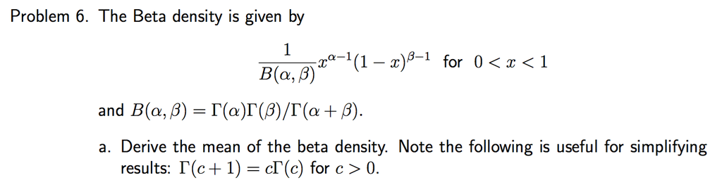

#### (a)

$$\begin{align*}
E[X] &= \int_0^1x\frac{1}{B(\alpha,\beta)}x^{\alpha-1}(1-x)^{\beta-1}dx\\
&= \frac{1}{B(\alpha,\beta)}\int_0^1 x^{\alpha}(1-x)^{\beta-1}dx\\
&= \frac{1}{B(\alpha,\beta)}B(\alpha+1,\beta) \;\;\;\; \text{(definition of beta function)} \\
&= \frac{\Gamma(\alpha+\beta)}{\Gamma(\alpha)\Gamma(\beta)}\frac{\Gamma(\alpha+1)\Gamma(\beta)}{\Gamma(\alpha+\beta+1)}\\
&= \frac{\Gamma(\alpha+1)}{\Gamma(\alpha)}\frac{\Gamma(\alpha+\beta)}{\Gamma(\alpha+\beta+1)}\\
&=\frac{\alpha}{\alpha+\beta} \;\;\;\; \text{(Property of gamma function }\Gamma(c+1)=c\Gamma(c)\text{)}
\end{align*}$$

### HW2 Problem 7

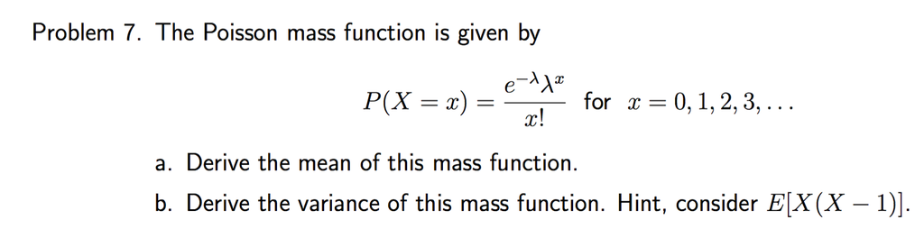

#### (a)

$$\begin{align*}
E[X] &= \sum\limits_{x=0}^{\infty} x\frac{e^{-\lambda}\lambda^x}{x!} = \sum\limits_{x=1}^{\infty} x\frac{e^{-\lambda}\lambda^x}{x!} \;\;\;\; \text{(the first term is 0)} \\
& = \lambda\sum\limits_{x=1}^{\infty} \frac{e^{-\lambda}\lambda^{x-1}}{(x-1)!} = \lambda\sum\limits_{y=0}^{\infty} \frac{e^{-\lambda}\lambda^{y}}{y!} \;\;\;\; \text{(change of variable }y=x-1\text{)} \\
&= \lambda \;\;\;\; \text{(sum of poisson PMFs is equal to 1)}
\end{align*}$$

#### (b)

$$\begin{align*}
E[X^2] &= E[X(X-1)] + E[X] \\
&= \sum\limits_{x=0}^{\infty} x(x-1)\frac{e^{-\lambda}\lambda^x}{x!} + E[X] \\
&= \sum\limits_{x=2}^{\infty} x(x-1)\frac{e^{-\lambda}\lambda^x}{x!} + E[X] \;\;\;\; \text{(the first and second terms are 0)} \\
&= \lambda^2\sum\limits_{x=2}^{\infty} \frac{e^{-\lambda}\lambda^{x-2}}{(x-2)!} + E[X] \\
&= \lambda^2\sum\limits_{y=0}^{\infty} \frac{e^{-\lambda}\lambda^{y}}{y!} + E[X] \;\;\;\; \text{(change of variable }y=x-2\text{)} \\
&= \lambda^2+\lambda \\
var(X) &= E[X^2]-E[X]^2 = \lambda.
\end{align*}$$

### HW2 Problem 9

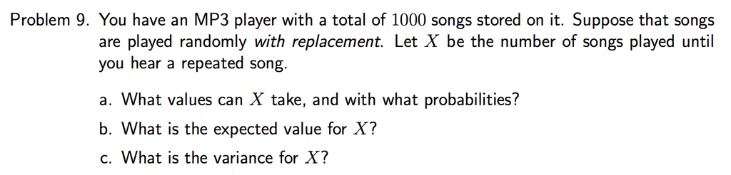

#### Solution 1

##### (a)

Let $x$ be the number of songs played until you hear a repeated song. That is, $x-1$ distinct songs have been played and the $x$th song is a repeat of one of the previous $x-1$ songs. Note that,

- We must play at least $1$ song before we can hear a repeated song, so $x \geq 2$.
- Since there are only $1000$ unique songs, by song $1001$, at least one song must be repeated.

Thus, $X$ can take on values from $2$ to $1001$.

To determine the probabilities, suppose the $x$th song played is the first repeated song. Then,
$$P(X = x) = \frac{\text{$\#$ ways $x$ songs are played with the $x$th song being the only repeated song}}{\text{$\#$ ways to play $x$ songs}}$$
Let us first consider the denominator.

- For the first song played, we have $1000$ options.
- Similarly, for the second song, we have $1000$ options since we have no restrictions on repetition.
- Continuing, for th $x$th song played, we still have $1000$ options.

Thus, the total number of ways to play $x$ songs is $1000^x$.

Now consider the numerator.

- For the first song played, we have $1000$ options.
- However, for the second song, we only have $999$ options since the first song cannot be played again, otherwise we would have a repetition.
- Continuing for the $(x-1)$th song, we have $1000 - (x-2)$ options since $x-2$ songs have already been played.
- For the $x$th song there are $x-1$ options since it must repeat one of the previous $x-1$ songs.

Thus, the total number of ways to play $(x-1)$ songs with no repeats and $x$-th being a repeat of one of the previous $x-1$ songs is:
$$[1000 \cdot (1000 - 1) \cdots (1000 - (x-2))] (x-1) = \frac{1000!}{(1000 - (x-1))!}\cdot(x-1)$$

Combining, we have
$$P(X = x) = \frac{1000!(x-1)}{(1000 - (x-1))!\cdot 1000^x} \quad \quad \text{ for } x = 2, 3, ..., 1001$$

#### Solution 2 (optional)

Note that the closed form solution for $P(X = x)$ is not very tractable due to the large factorials. For the sake of calculating the expectation and variance, it is more practical to define $P(X = x)$ recursively.

Consider $X=1$. $P(X=1) = 0$ trivially.
$$\begin{eqnarray}
P(X=2 \cap X > 1) & = & P(X=2 \cap X > 1| X > 1)P(X > 1) \phantom{00}\text{Definition of conditional probability} \nonumber \\
& = & P(X=2 | X > 1)P(X > 1) \nonumber \\
& = & \frac{1}{1000} \times \frac{1000}{1000} \nonumber
\end{eqnarray}$$

Similarly,
$$\begin{eqnarray}
P(X=3 \cap X > 2) & = & P(X=3 \cap X > 2| X > 2)P(X > 2) \phantom{00}\text{Definition of conditional probability} \nonumber \\
& = & P(X=3 | X > 2)P(X > 2) \nonumber \\
& = & \frac{2}{1000} \times (1- (P(X=2) + P(X=1))) \nonumber \\
& = & \frac{2}{1000} \times \left(1- \frac{1}{1000}\right) \nonumber
\end{eqnarray}$$

This can be repeated for $k = 1, 2, \ldots, 1001$

$$\begin{eqnarray}
P(X=k) & = & P(X=k | X > k-1)P(X > k-1) \nonumber \\
& = & \frac{k-1}{1000}\left(1 - \sum_{i=1}^{k-1}P(X=i)\right) \nonumber
\end{eqnarray}$$

##### (b) What is the expected value for $X$?

$E[X] = \sum_{k=1}^{n+1} k P(X=k) = 40.30$ See R-output below for calculation.

##### (c) What is the variance for $X$?

$\text{Var}(X) = \sum_{k=1}^{n+1} k^2 P(X=k) - E[X]^2 = 415.95$ See R-output below for calculation.

```r
nsongs <- 1000

## Vector of possible values of x for x=1,...,1001
xk <- 1:(nsongs+1)

## (Placeholder) vector of probabilities of P(X=x) for x=1,...,1001
pk <- rep(0, nsongs+1)

## Compute vector of probabilities of P(X=x) for x=1,...,1001 in a loop
for(k in 1:length(pk)){
    pk[k] <- (k-1)/nsongs * (1-sum(pk[1:(k-1)]))
}

EX <- sum(pk * xk)
VX <- sum(pk * xk^2) - EX^2

EX; VX
```

```
## [1] 40.30321
```

```
## [1] 415.9542
```

### 2009 midterm Problem 2

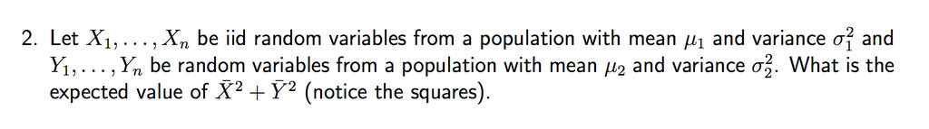

$$\begin{align*}
E[\bar{X}^2] &= var(\bar{X}) + E[\bar{X}]^2 \\
&= \frac{1}{n^2}var\Big(\sum_{i=1}^n X_i\Big) + \Big(\frac{1}{n}E\Big[\sum_{i=1}^n X_i\Big]\Big)^2 \\
&= \frac{1}{n^2}\Big(\sum_{i=1}^n var(X_i)\Big) + \Big(\frac{1}{n}nE[X_1]\Big)^2 \;\;\;\; \text{(}X_1,X_2,...,X_n\text{ are iid)} \\
&= \frac{1}{n^2}n\sigma_1^2+\mu_1^2 \\
&= \frac{1}{n}\sigma_1^2+\mu_1^2 \\
E[Z] & = (\sigma_1^2+\sigma_2^2)/n+\mu_1^2+\mu_2^2.
\end{align*}$$

### 2009 midterm Problem 6-8

#### Q6

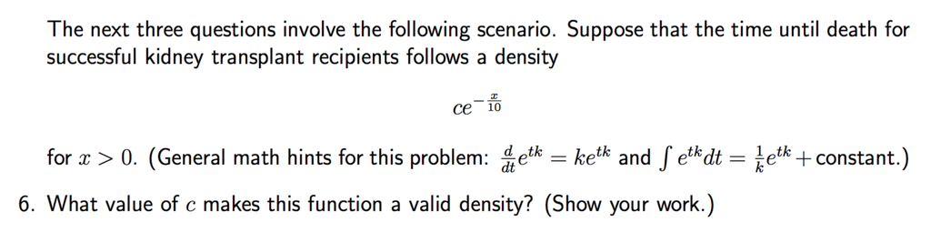

$c$ should be positive and the density should integrate to 1.
$$\int_0^{\infty} ce^{-\frac{x}{10}}dx = c(-10e^{-\frac{x}{10}})\Big|_0^{\infty}=10c.$$

Set $10c=1$ and we have $c=1/10$.

#### Q7

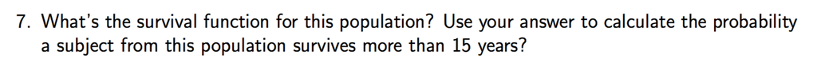

The survival function is
$$\begin{align*}
S(t) = P(X>t) = \int_t^{\infty}\frac{1}{10}e^{-1/10}dx = (-e^{-\frac{x}{10}})\Big|_t^{\infty}=e^{-t/10}.
\end{align*}$$

The probability that a subject from this population survives more than 15 years is
$$S(15) = e^{-15/10} = 0.22$$

#### Q8

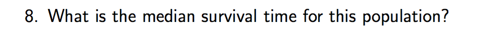

To calculate the median survival time, solve the equation $S(t)=0.5$. Therefore
$$t_{median} = -10\log(0.5)\approx 6.93$$
.